# Project 1

Qinzhi Peng

Fall 2022

## Exploratory Data Anaylsis

### Basic Information

#### Data Structure

Get some basic information for this data set.

```r
str(df)
```

```
## 'data.frame':    310 obs. of  10 variables:
##  $ Income   : num  14.9 106 104.6 148.9 55.9 ...
##  $ Limit    : int  3606 6645 7075 9504 4897 8047 3388 7114 3300 6819 ...
##  $ Rating   : int  283 483 514 681 357 569 259 512 266 491 ...
##  $ Cards    : int  2 3 4 3 2 4 2 2 5 3 ...
##  $ Age      : int  34 82 71 36 68 77 37 87 66 41 ...
##  $ Education: int  11 15 11 11 16 10 12 9 13 19 ...
##  $ Gender   : Factor w/ 2 levels " Male","Female": 1 2 1 2 1 1 2 1 2 2 ...
##  $ Student  : Factor w/ 2 levels "No","Yes": 1 2 1 1 1 1 1 1 1 2 ...
##  $ Married  : Factor w/ 2 levels "No","Yes": 2 2 1 1 2 1 1 1 1 2 ...
##  $ Balance  : int  333 903 580 964 331 1151 203 872 279 1350 ...
```

There are 310 rows and 10 columns in the data set. It contains 9 explanatory variables - 6 numeric variables that are `Income`, `Limit`, `Rating`, `Cards`, `Age`, and `Education`, 3 factor variables that are `Gender`, `Student`, and `Married`, and a response variable that is `Balance`.

#### Observations

We can also see a few observations below. It seems that there are no obviously non-informative columns.

```r
head(df)
```

```
##    Income Limit Rating Cards Age Education Gender Student Married Balance
## 1  14.891  3606    283     2  34        11   Male      No     Yes     333
## 2 106.025  6645    483     3  82        15 Female     Yes     Yes     903
## 3 104.593  7075    514     4  71        11   Male      No      No     580
## 4 148.924  9504    681     3  36        11 Female      No      No     964
## 5  55.882  4897    357     2  68        16   Male      No     Yes     331
## 6  80.180  8047    569     4  77        10   Male      No      No    1151
```

#### Summary

Get a textual summary of the data set and see if there are missing data or if anything appears weird.

```r
summary(df)
```

```
##      Income           Limit           Rating          Cards
##  Min.   : 10.35   Min.   : 1160   Min.   :126.0   Min.   :1.000
##  1st Qu.: 23.15   1st Qu.: 3976   1st Qu.:304.0   1st Qu.:2.000
##  Median : 37.14   Median : 5147   Median :380.0   Median :3.000
##  Mean   : 49.98   Mean   : 5485   Mean   :405.1   Mean   :2.997
##  3rd Qu.: 63.74   3rd Qu.: 6453   3rd Qu.:469.0   3rd Qu.:4.000
##  Max.   :186.63   Max.   :13913   Max.   :982.0   Max.   :9.000
##       Age          Education        Gender    Student   Married
##  Min.   :23.00   Min.   : 5.00    Male :145   No :271   No :118
##  1st Qu.:42.00   1st Qu.:11.00   Female:165   Yes: 39   Yes:192
##  Median :55.50   Median :14.00
##  Mean   :55.61   Mean   :13.43
##  3rd Qu.:69.00   3rd Qu.:16.00
##  Max.   :98.00   Max.   :20.00
##     Balance
##  Min.   :   5.0
##  1st Qu.: 338.0
##  Median : 637.5
##  Mean   : 671.0
##  3rd Qu.: 960.8
##  Max.   :1999.0
```

From the summary, it seems that there are no missed values or weird values in the data set. We can check that there are no NA values as well.

```r
which(is.na(df))
```

```
## integer(0)
```

### Data Distributions

#### Response Variable

Show the distribution of the response variable `Balance`.

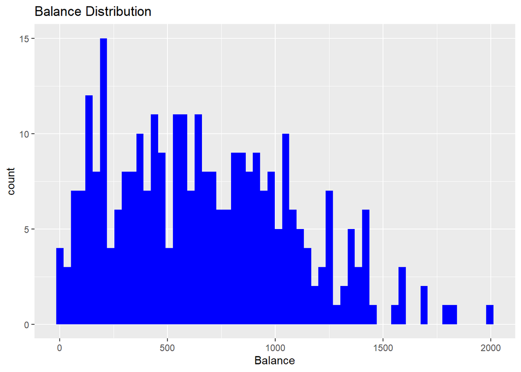

```r
ggplot(data = df, mapping=aes(x = Balance)) +
  geom_histogram(fill="blue", bins=60) +
  ggtitle("Balance Distribution")
```

We can see that most of values lie between 0 and 1500. There is only one person whose balance is 1999.

#### Quantitative Predictors

Create a faceted histogram for all quantitative predictors that are `Income`, `Limit`, `Rating`, `Cards`, `Age`, and `Education`.

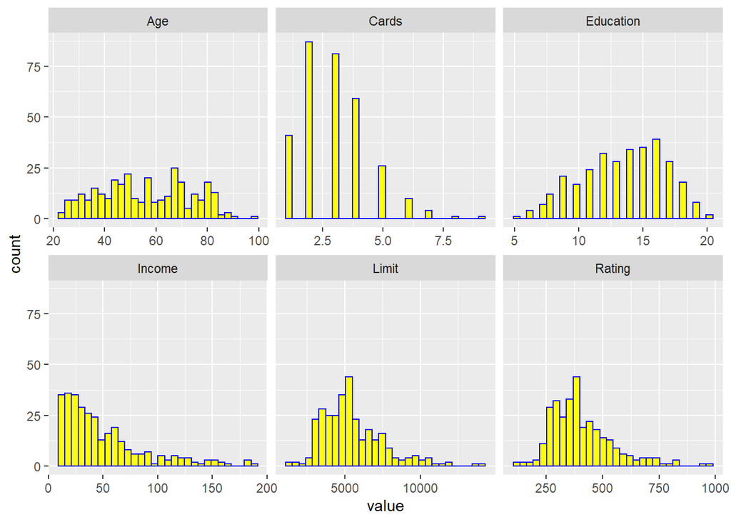

```r
df.qnt <- df %>%
  dplyr::select(Income, Limit, Rating, Cards, Age, Education) %>%
  gather()

#  visualize the data in multiple columns, side by side
ggplot(data = df.qnt, mapping = aes(x = value)) +
  geom_histogram(color = "blue", fill = "yellow", bins = 30) +
  facet_wrap(~ key, scales = 'free_x')
```

We can see the `Age` are relatively uniformly distributed with most of values lying between 20 and 85. For the `Cards`, most of people have less than 5 cards, and only one person has 8 cards and one has 9 cards. the `Education` seems to be normally distributed, and only one person has level 5 education and two have level 20 education. the `Income` is right skew, we may handle this depend on models we will use in the future. For the `Limit` and `Rating`, there are also some big outliers we may need to handle later.

#### Categorical Predictors

Create a faceted histogram for all categorical predictors that are `Gender`, `Student`, and `Married`.

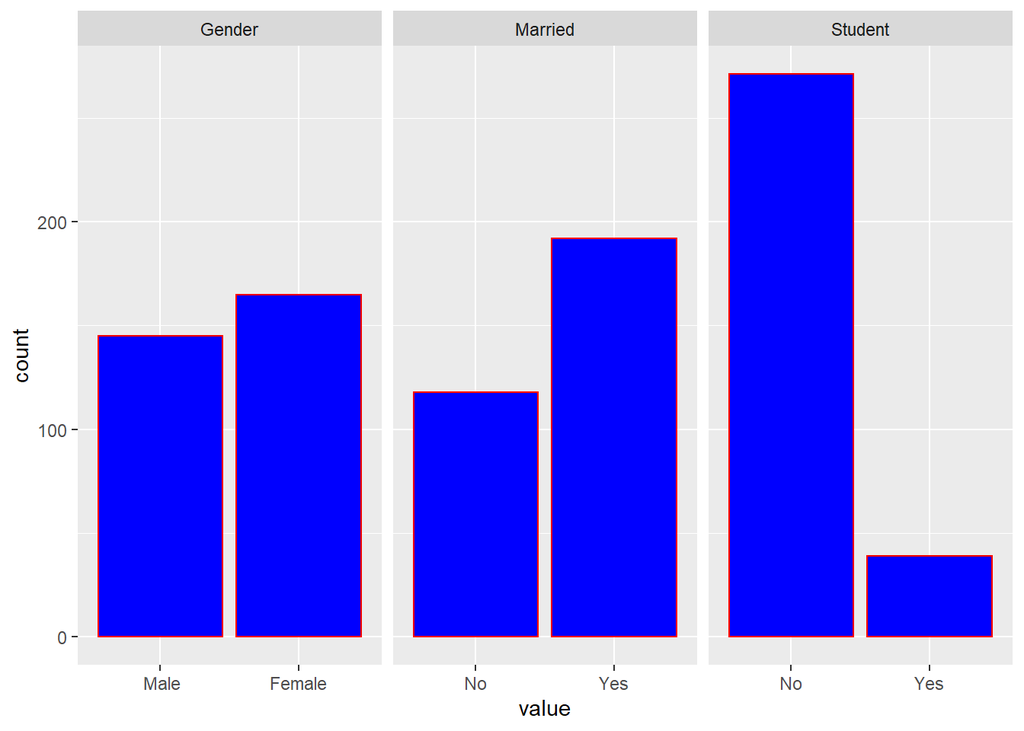

```r
df.cat <- df %>%
  dplyr::select(Gender, Student, Married) %>%
  gather()

#  visualize the data in multiple columns, side by side
ggplot(data = df.cat, mapping = aes(x = value)) +
  geom_bar(color="red",fill="blue") +
  facet_wrap(~ key, scales = 'free_x')
```

In this data set, there are similar numbers of males and females, more people who are married, and more people who are not students.

### Data Statistics

#### Quantitative Predictors

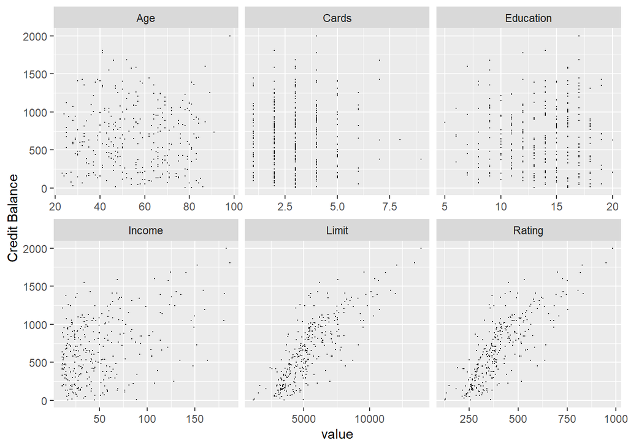

```r
num.qnt <- 6
ggplot(data = df.qnt, mapping = aes(x = value, y = rep(df$Balance, num.qnt))) +
  geom_point(size = 0.1) +
  facet_wrap(~ key, scales = 'free_x') +
  ylab("Credit Balance")
```

There is a outlier in the data set. we need to analysis this observation below.

```r
df[which(df$Balance == max(df$Balance)),]
```

```
##      Income Limit Rating Cards Age Education Gender Student Married Balance
## 247 182.728 13913    982     4  98        17   Male      No     Yes    1999
```

Although it is an outlier, we should not remove it, since the person has high-level education, great age, high limit, rating and income, it makes sense that he has a great credit balance.

#### Categorical Predictors

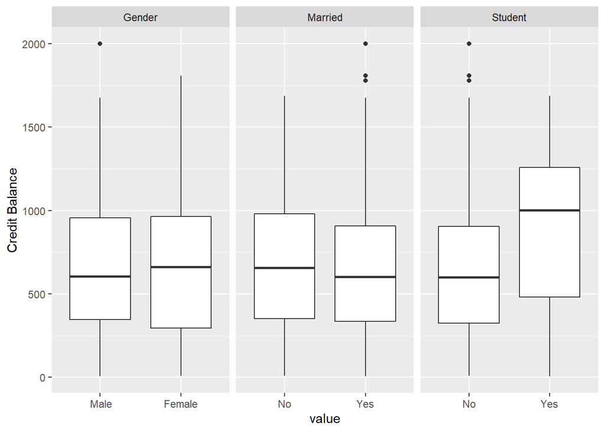

```r
num.cat <- 3
ggplot(data = df.cat, mapping = aes(x = value, y = rep(df$Balance, num.cat))) +
  geom_boxplot() +
  facet_wrap(~ key, scale = 'free_x') +
  ylab("Credit Balance")
```

We can see that females appear to have greater balance than males, and people who are not married appear to have greater balance than those who are married. It is noteworthy that students have much greater credit balances than non-students.

### Correlation

#### All predictors

Visually determine the level of correlation between all the predictor variables.

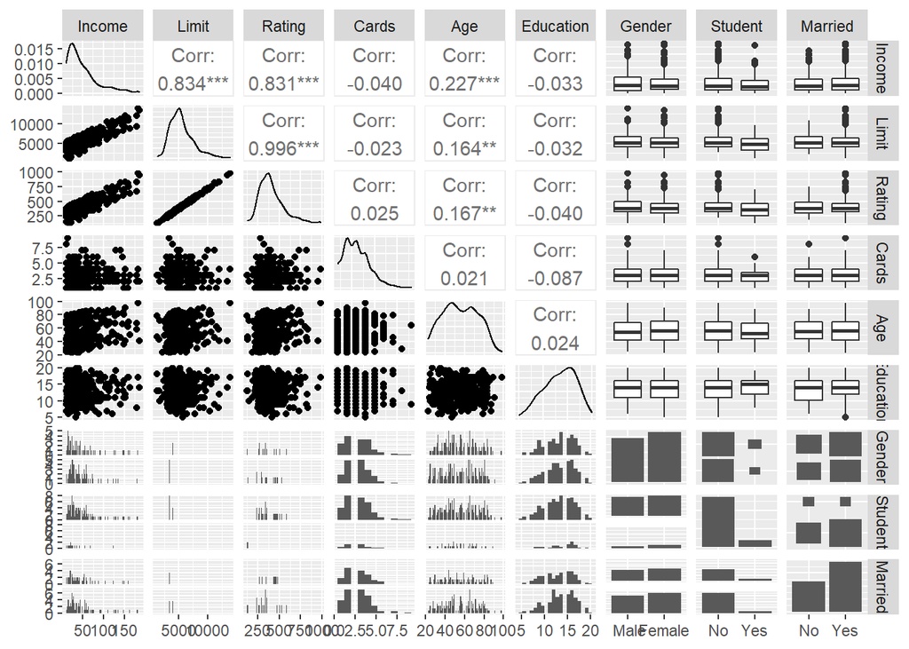

```r
df %>%
  dplyr::select(Income, Limit, Rating, Cards, Age, Education, Gender, Student, Married) %>%
  ggpairs(lower = list(combo = wrap("facethist", binwidth = 0.8)), progress=FALSE)
```

We can see the correlation coefficients within the `Income`, `Limit`, and `Rating` are all greater than 0.8, which means they are mutually highly correlated. There are some relationships between `Student` and `Age` as well as `Student` and `Education`, which makes sense since students are always young people with higher education. Among all categorical predictors, there seems to be a correlation between the `Student` and `Married`, we will check it later. It is noteworthy that the number of students is relatively small in this data set, we may need more sample to get a reasonable conclusion.

#### Quantitative Predictors

Show a correlation plot between all quantitative predictor variables since the `ggpairs` plot gets messy above.

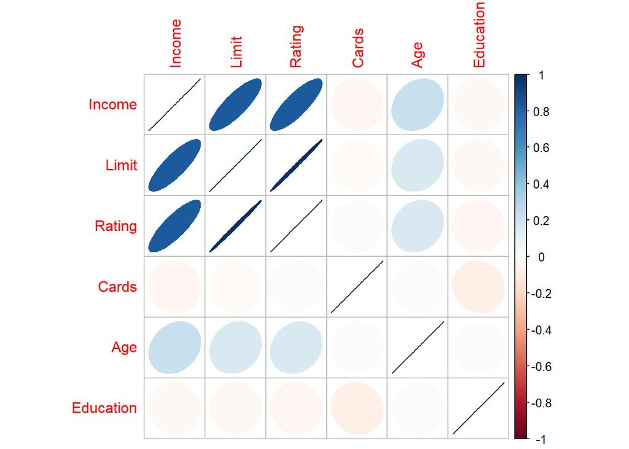

```r
df %>%
  dplyr::select(Income, Limit, Rating, Cards, Age, Education) %>%
  cor() %>%
  corrplot(method="ellipse")
```

We can clearly see that `Income`, `Limit`, and `Rating` are mutually correlated. In order to achieve better results, we may need to drop the redundant predictors in models.

#### Categorical Predictors

Show a table between the `Student` and `Married`.

```r
table(df$Student, df$Married)
```

```
##
##        No Yes
##   No   98 173
##   Yes  20  19
```